# 2015_Q

Jake Cavaiani

9/22/2022

## French and Moose 2015 Discharge

The purpose of this script is to import raw PT data from each of our sites in 2015 (Moose, French), clean (out of water points, potential beaver dams, noisy data, remove a PT if data is bad etc.) and prepare to convert to continuous predicted discharge (Q)

Important NOTES: 1) Water level data is obtained from HOBO pressure transducers (PTs) that were installed in PVC pipes in streams, with the PT sitting on top of a rebar piece at bottom of pipe. Raw pressure from PTs were processed in HOBOware to correct for atmospheric pressure to get water depth. Atmospheric pressure was obtained from a PT installed at each site in a tree. HOWEVER, water depth is absolute PT depth, NOT actual water depth. To get actual water depth, we need a reference water depth from a time point in the water depth time series that is an accurate measure of the depth of the pt from the water surface. We do not have these (depth measurements from flow meter measurements were not done sufficiently close to PT locations to use).We have waterlevel surveys from Kate Broberg in 2020 and 2021 We must therefore rely on the rating curve to convert absolute water depth to continuous Q.

Step 1: import raw data hoboware files which is site, datetime, absolute pressure and water level Step 2: Clean errant points within the data that could be due to installation/decommission or gaps in data Step 3: Write final output of cleaned site, datetime, absolute pressure and water level Step 4: import Qsummary document to generate rating curves of Q and pressure Step 5: clean errant points in regression Step 6: apply rating curve to generate continuous predicted discharge at each site Step 7: Output final discharge as csv.

2015 data is read from DoD->2015 AK sensors->Discharge->discharge->pressure transducer-> “PT_Site_Compiled” 2015 data was taken att 5 minute intervals

### Observed Discharge at French and Moose

Slugs were the only method of discharge for 2015

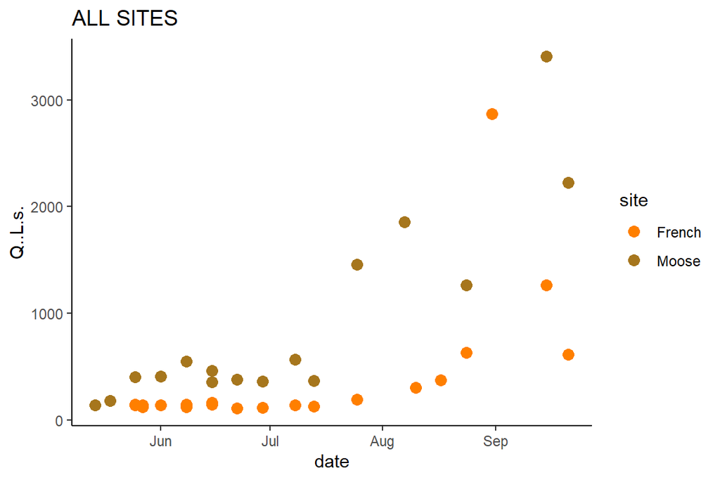

This is from the DOD Q Summary csv that is DoD Project->2015 AK sensors ->Discharge

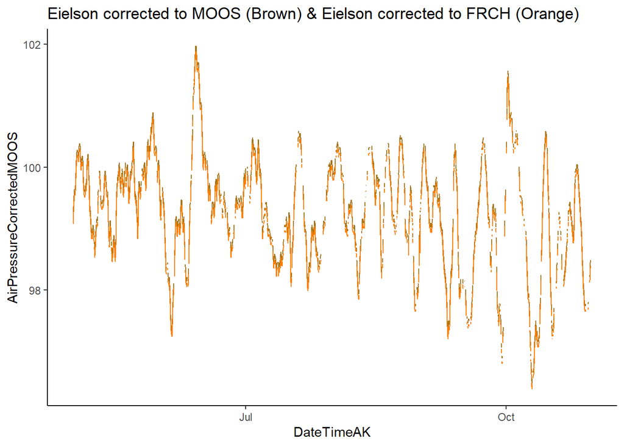

```r
eielson.atmo.2015.url <- "https://docs.google.com/spreadsheets/d/e/2PACX-1vSx5CyMTHZWjvTaYfNQcDZw7U59URY8v6PSJvH4bGwjtSkbD0picwdOJCyBqg3_BGcjwHztwT0b1sQT/pub?output=csv"

eielson.atmo.2015 <- read.csv(url(eielson.atmo.2015.url), skip = 6)
eielson.atmo.2015 <- eielson.atmo.2015[-1,]

names(eielson.atmo.2015) <- c("Site", "DateTimeAK", "sea_level_pressure", "1_day")

eielson.atmo.2015$DateTimeAK <- mdy_hm(eielson.atmo.2015$DateTimeAK)

eielson.atmo.2015$DateTimeAK <- force_tz(eielson.atmo.2015$DateTimeAK, "America/Anchorage")

eielson.atmo.2015$DateTimeAK <- lubridate::round_date(eielson.atmo.2015$DateTimeAK, "15 minutes")


eielson.atmo.2015$AirPressure <- as.numeric(eielson.atmo.2015$sea_level_pressure)
eielson.atmo.2015$sea_level_pressure <- as.numeric(eielson.atmo.2015$sea_level_pressure)

eielson.atmo.2015$AirPressure <- eielson.atmo.2015$AirPressure*3.38639 # converting from inHG to kPa

eielson.atmo.2015 <- subset(eielson.atmo.2015, DateTimeAK > "2015-05-01" & DateTimeAK < "2015-10-31")

# correcting for elevation
eielson.atmo.2015$mmHG <- eielson.atmo.2015$sea_level_pressure * 25.44 # converting to mmHG

# conversion to elevation at each site
# MOOS
eielson.atmo.2015$mmHGcorrectedMOOS <- eielson.atmo.2015$mmHG - (2.5*574/100)

eielson.atmo.2015$AirPressureCorrectedMOOS <- eielson.atmo.2015$mmHGcorrectedMOOS * 0.133322 # converting this to kPA to compare with MOOS PT

# FRCH
eielson.atmo.2015$mmHGcorrectedFRCH <- eielson.atmo.2015$mmHG - (2.5*601/100)

eielson.atmo.2015$AirPressureCorrectedFRCH <- eielson.atmo.2015$mmHGcorrectedFRCH * 0.133322 # converting this to kPA



ggplot(aes(x = DateTimeAK, y = AirPressureCorrectedMOOS), data = eielson.atmo.2015) +
  geom_line(aes(x = DateTimeAK, y = AirPressureCorrectedMOOS), data = eielson.atmo.2015, color="#A6761D") +
  geom_line(aes(x = DateTimeAK, y = AirPressureCorrectedFRCH), data = eielson.atmo.2015, color="#FF7F00") +
  theme_classic() +
  ggtitle("Eielson corrected to MOOS (Brown) & Eielson corrected to FRCH (Orange)")
```

## Raw Moose

There is a big increase in middle to end of may that doesnt seem to be real from precip , and then a lot of vertical drops in middle of June, July, August (potentially cleanning points) and then at the end of september we get a big drop, this is when the site was taken out…(PT was taken out on the 21st)… let the cleaning commence!

## Moose 1.0

```
## [1] 4148 5366 5367 5368 5369 5370 5371 5372 5373
```

```
## [1] 2143
```

```
## [1] 2775 2776 2777
```

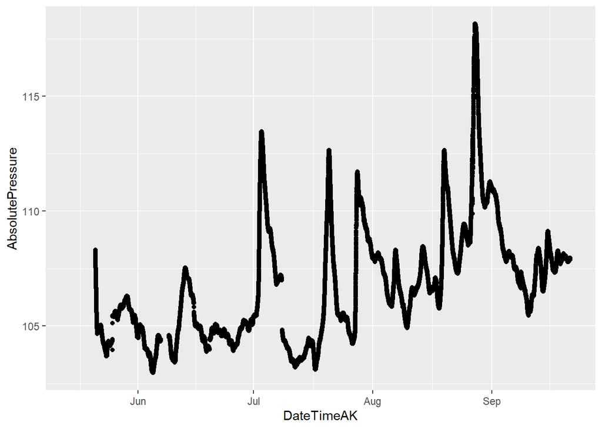

1) Clipped off the take out date (anything after 2015-09-20 18:30:00) 2) Set vertical drops in raw data to NA’s

I will clean up the jumps.

```r
# Shift following pressure up after Jul 8 jump:
moos.stream[15821,2] - moos.stream[15823,2]
```

```
## [1] 2.182
```

```r
moos.stream <- moos.stream %>%
  mutate(across(c(AbsolutePressure),
                ~ifelse(DateTimeAK >= "2015-07-08 10:40:00", AbsolutePressure + 2.182, .)))

# Shift following pressure up after May 25 jump:
moos.stream[3146,2] - moos.stream[3149,2]
```

```
## [1] -0.993
```

```r
moos.stream <- moos.stream %>% filter(DateTimeAK < "2015-05-25 10:15:00" | DateTimeAK > "2015-05-25 10:30:00") %>%
  mutate(across(c(AbsolutePressure),
                ~ifelse(DateTimeAK > "2015-05-25 10:15:00", AbsolutePressure - 0.993, .)))

# Shift following pressure up after Jun 19 jump:
moos.stream[10403,2] - moos.stream[10413,2]
```

```
## [1] NA
```

```r
moos.stream <- moos.stream %>%
  mutate(across(c(AbsolutePressure),
                ~ifelse(DateTimeAK > "2015-06-19 15:05:00", AbsolutePressure - 0.468, .)))


# Shift following pressure up after Sep 7 jump:
moos.stream[33693,2] - moos.stream[33694,2]
```

```
## [1] 0.01
```

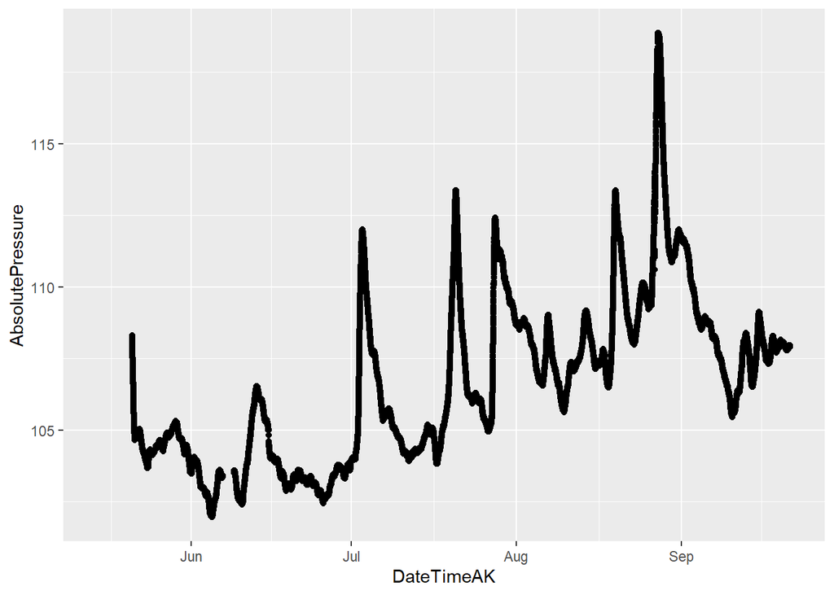

```r
moos.stream <- moos.stream %>%
  mutate(across(c(AbsolutePressure),
                ~ifelse(DateTimeAK > "2015-09-08 12:30:00", AbsolutePressure - 0.714, .)))


moos.stream %>% #filter(DateTimeAK > "2015-05-01" & DateTimeAK < "2015-5-30") %>%
  ggplot(aes(x = DateTimeAK, y = AbsolutePressure)) +
  geom_point()
```

### Impute missing observations in pressure for Moose

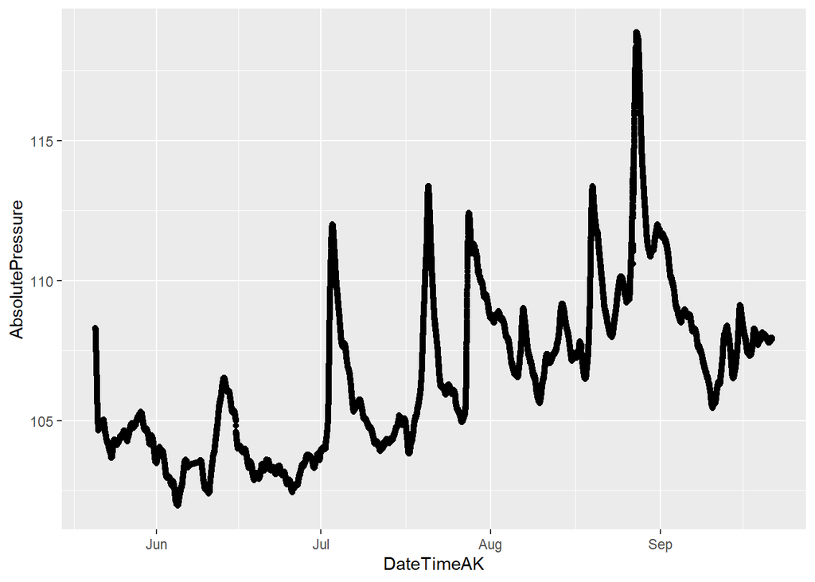

## Raw FRCH

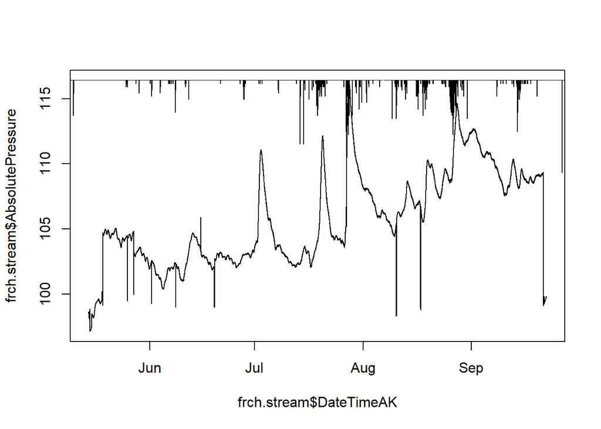

Similarily to Moose There is a big increase in middle to end of may that doesnt seem to be real from precip , and then a lot of vertical drops in middle of June, July, August (potentially cleanning points) and then at the end of september we get a big drop, this is when the site was taken out…(PT was taken out on the 21st)… let the cleaning commence!

### French 1.0

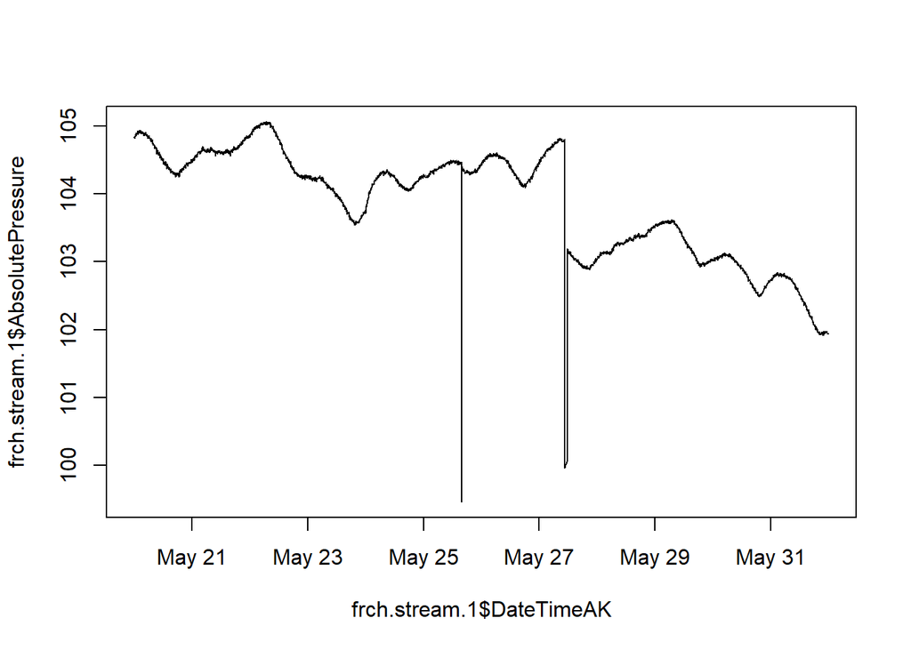

```
##  [1] 1631 2143 2144 2145 2146 2147 2148 2149 2150 2151 2152 2153 2154 2155 2156
## [16] 3401 3402 3403 3404 3405 3406 3407 3408 3409 3410 3411 3412 3413 3414 3415
## [31] 3416 3417 3418 3419 3420 3421 3422 3423 3424 3425 3426 3427 3428 3429 3430
## [46] 3431 3432 3433 3434 3435 3436 3437 3438 3439 3440 3441 3442 3443 3444 3445
## [61] 3446 3447 3448 3449 3450 3451 3452 3453 3454 3455
```

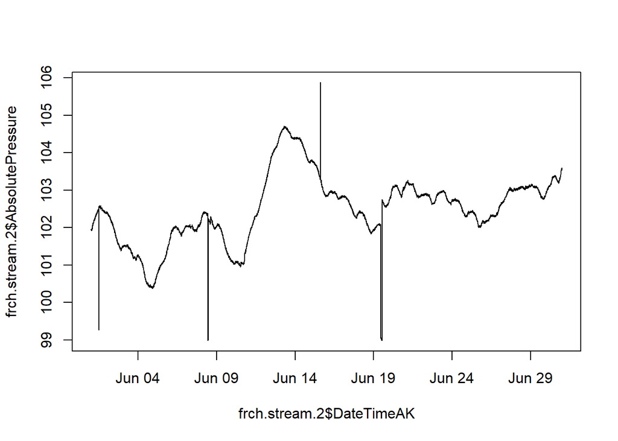

```
##  [1]  145 2148 5309 5310 5311 5312 5313 5314 5315 5316 5317 5318 5319 5320 5321
## [16] 5322 5323 5324 5325 5326 5327 5328 5329 5330 5331 5332 5333 5334 5335 5336
## [31] 5337
```

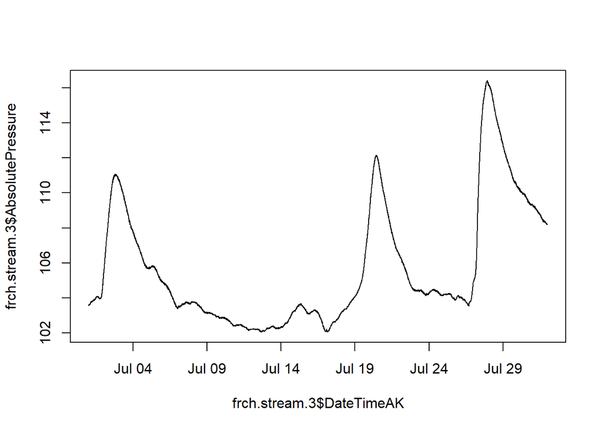

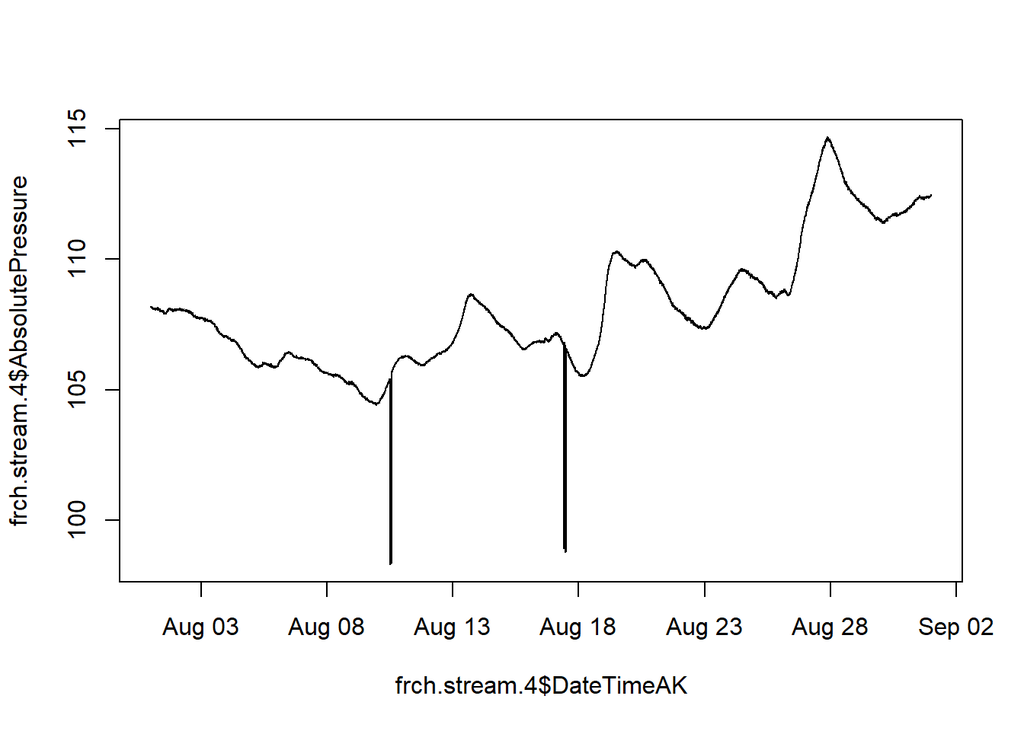

```
##  [1] 2737 2738 2739 2740 2741 2742 2743 2744 2745 2746 2747 2748 2749 2750 2751
## [16] 2752 4727 4728 4729 4750
```

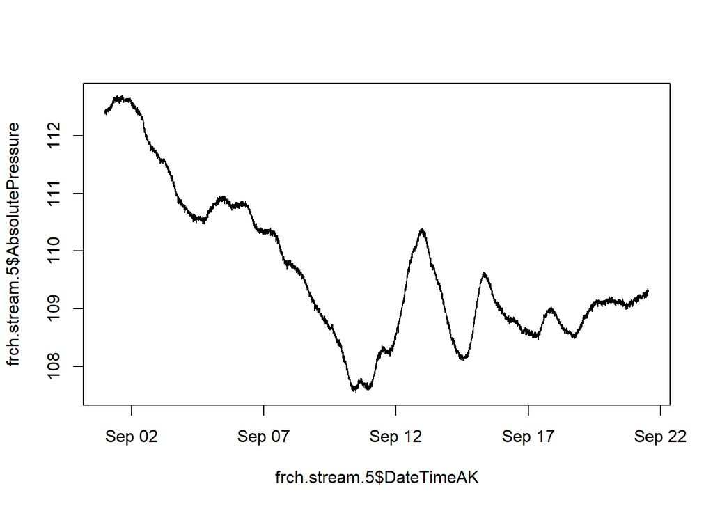

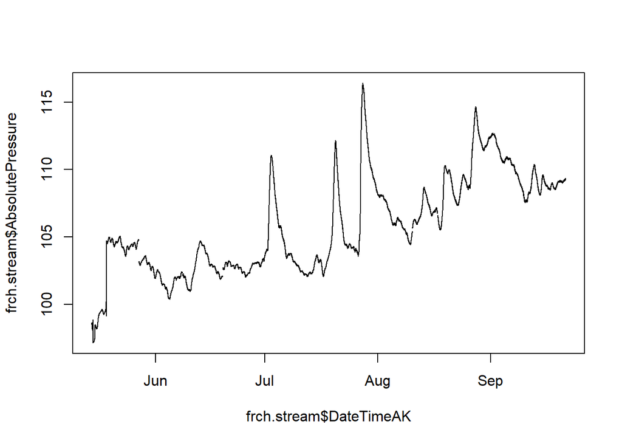

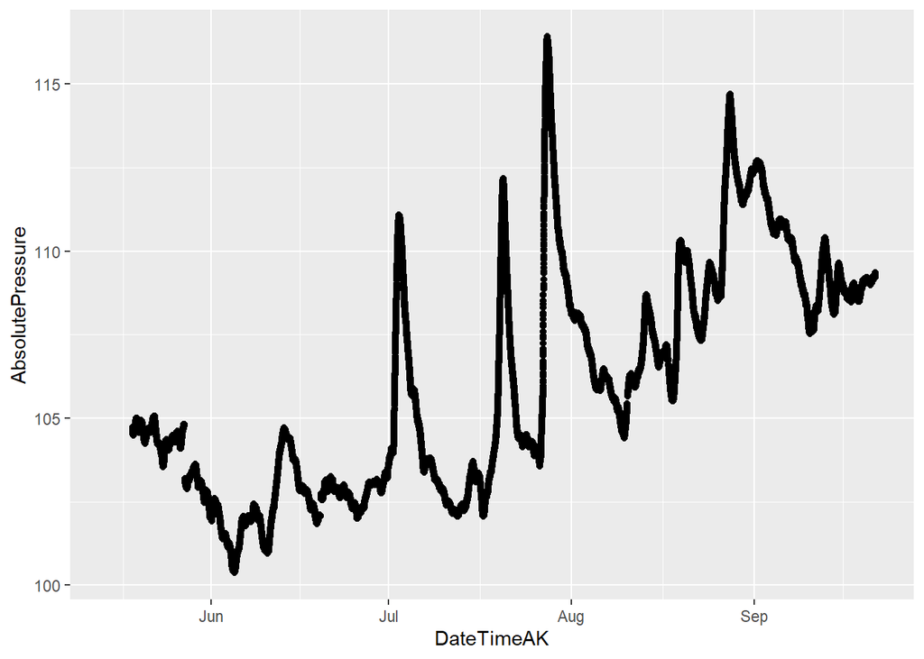

1) Clipped off the take out date (anything after 2015-09-20 18:30:00) 2) Set vertical drops in raw data to NA’s 3) NEED TO DO NA INTERPRET (na_kalman)

I will clean up the jumps.

```r
# Shift following pressure up after Jul 27 jump:
frch.stream[3726,2] - frch.stream[3741,2]
```

```
## [1] 1.64
```

```r
frch.stream <- frch.stream %>% filter(DateTimeAK >= "2015-05-18 15:15:00") %>%
  mutate(across(c(AbsolutePressure),
                ~ifelse(DateTimeAK > "2015-05-27 10:30:00
", AbsolutePressure + 1.64, .)))

# Shift following pressure up after Jul 19 jump:
frch.stream[9158,2] - frch.stream[9189,2]
```

```
## [1] -0.669
```

```r
frch.stream <- frch.stream %>% filter(DateTimeAK != "2015-06-19 13:15:00") %>%
  mutate(across(c(AbsolutePressure),
                ~ifelse(DateTimeAK > "2015-06-19 10:45:00
", AbsolutePressure - 0.669, .)))
```

### Impute missing observations in pressure for French

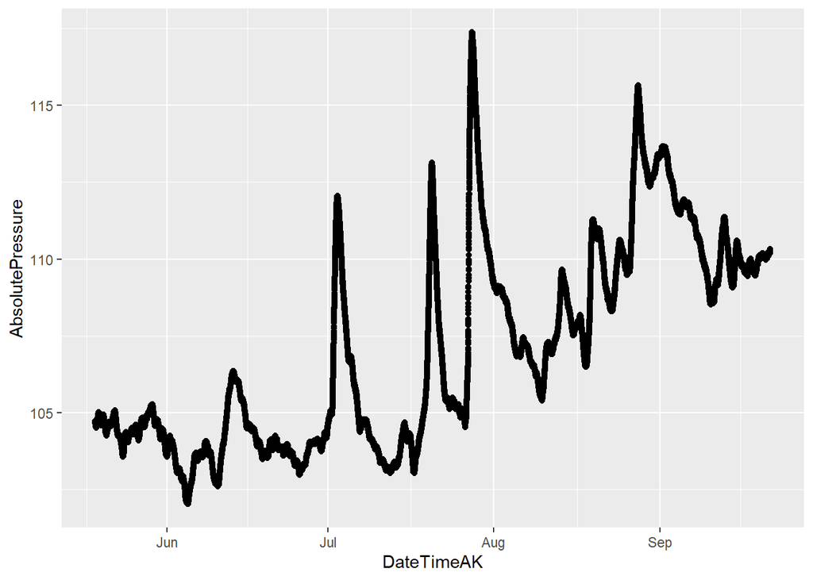

### Raw Rating Curve with Moose 1 Pressure Transducer

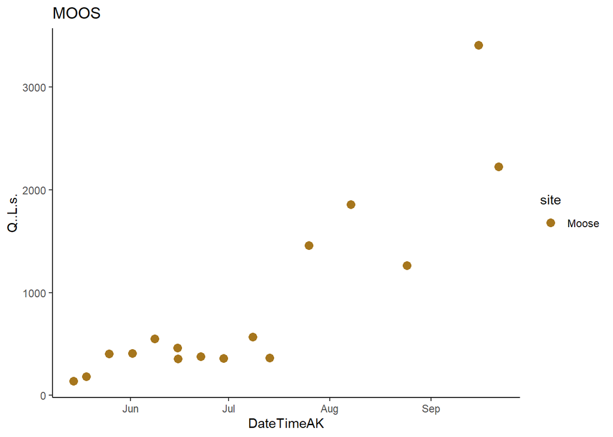

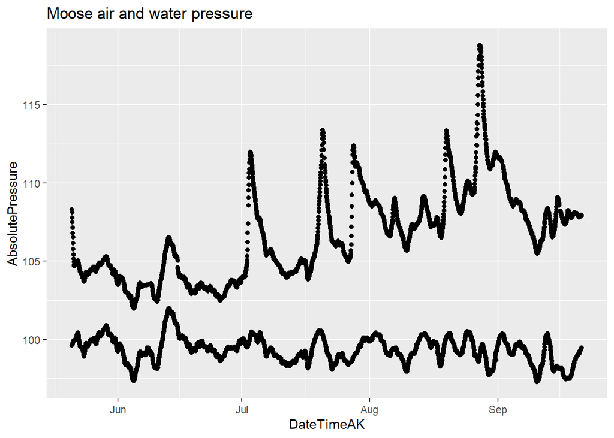

```r
### Filter MOOS ###
QSummary.MO <- QSummary %>% filter(site =="Moose")

ggplot(QSummary.MO) +
  geom_point(aes(x = DateTimeAK, y = Q..L.s., color = site), size=3) +
  theme_classic() +
  scale_color_manual(values=c("#A6761D")) +
  ggtitle("MOOS")
```

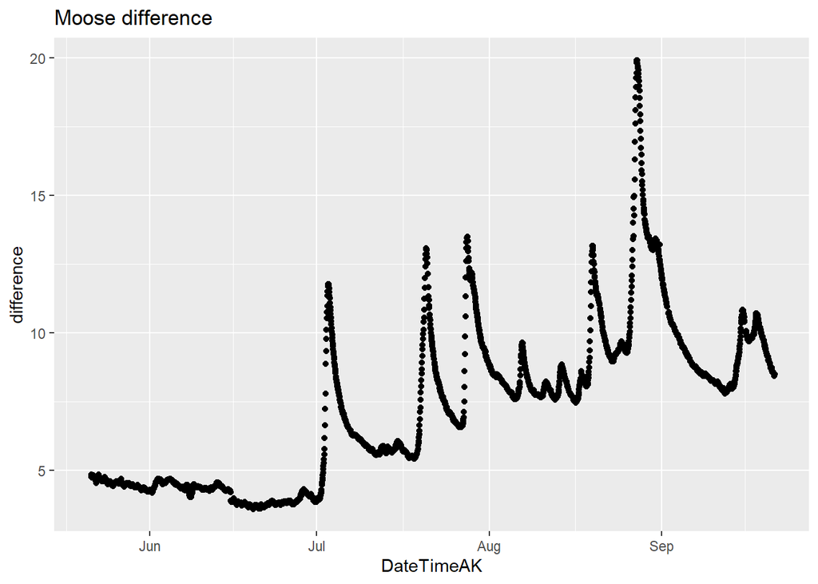

```r
# Water pressure - atmospheric pressure
MOOS.2015.one$difference <- MOOS.2015.one$AbsolutePressure - MOOS.2015.one$AirPressureCorrectedMOOS

# Remove spike at start because it doesn't match French
MOOS.2015.one <- MOOS.2015.one %>% mutate(across(c(difference), ~ifelse(DateTimeAK < "2015-06-01" & difference > 5, NA,.)))

MOOS.2015.one %>% ggplot(aes(DateTimeAK, difference)) + geom_point() + ggtitle("Moose difference")
```

```r
# trying to merge by nearest date if we have an offset point
MOOS.2015.one.dt <- setDT(MOOS.2015.one)
MOOS.2015.one.dt <- subset(MOOS.2015.one.dt, DateTimeAK < "2015-09-20 18:00:00") # removing rows that had dates corresponding to end of record that messed up the rolling nearest function
QSummary.MO.dt <- QSummary.MO

Moose1comb.2015 <- MOOS.2015.one.dt[QSummary.MO.dt, on = "DateTimeAK", roll = 'nearest']

MOOS1.lm.2015 <- lm(Moose1comb.2015$Q..L.s. ~ Moose1comb.2015$difference)
```

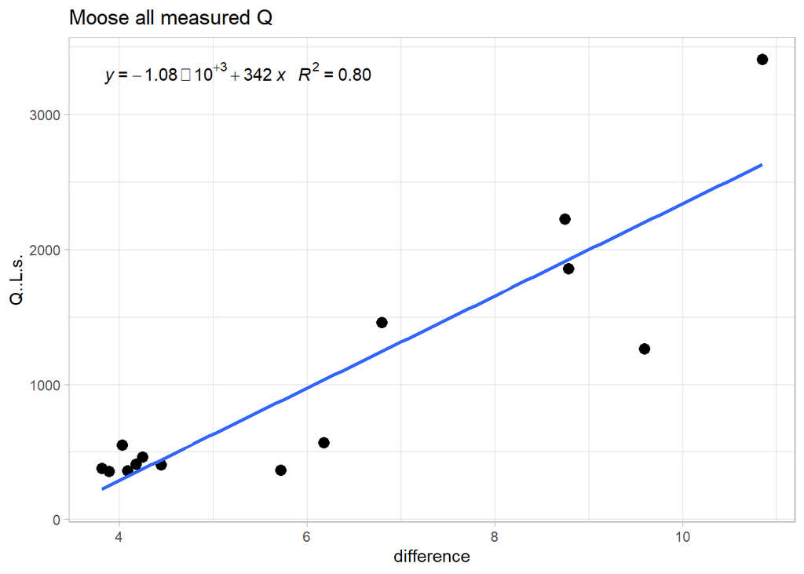

```r
# plot rating curve
moos.formula = y~x

ggplot(aes(x = difference, y = Q..L.s.), data = Moose1comb.2015) +
  geom_point(size = 3) +
  geom_smooth(method = "lm", se=FALSE, formula = moos.formula) +
  stat_poly_eq(formula = moos.formula,
               aes(label = paste(..eq.label.., ..rr.label.., sep = "~~~")),
               parse = TRUE) +
  #xlim(216, 216.4) +
  #ylim(0,1500) +
  theme_light() +
  ggtitle("Moose all measured Q")
```

The two low points at the big difference are probably not the best

### Rating Curve with Moose 1 Pressure Transducer 2.0

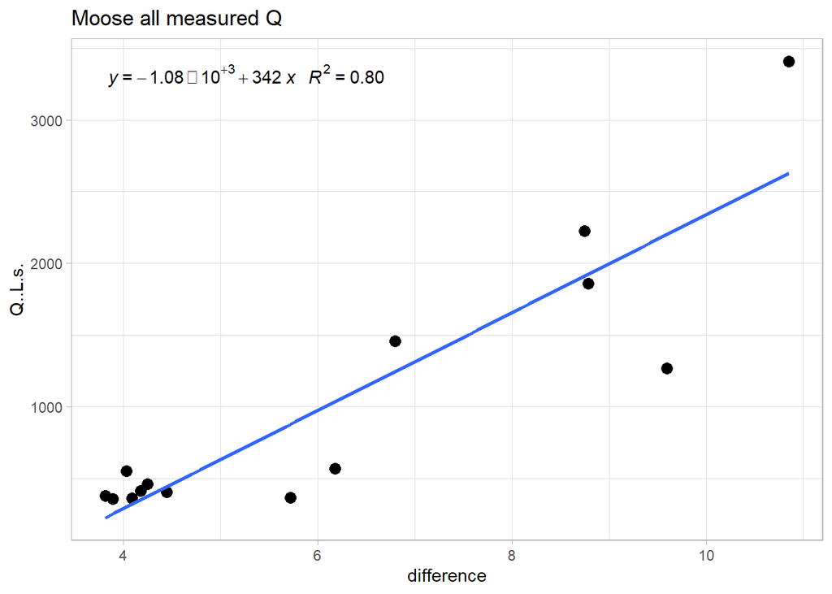

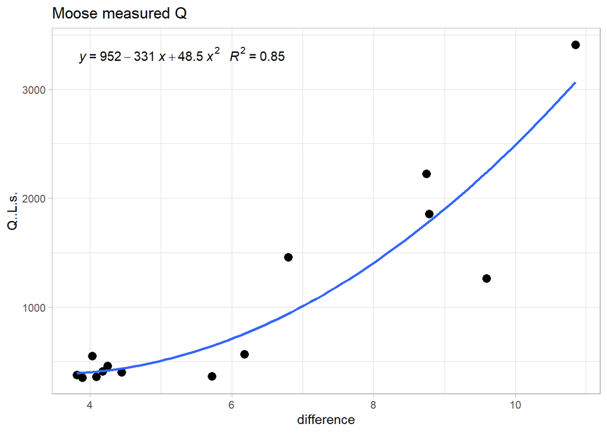

Plot predicted Q.

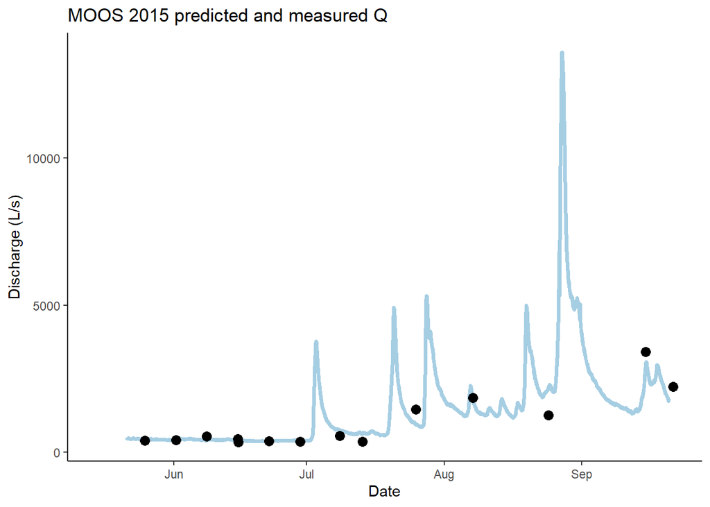

```r
## Predict MOOS Q
MOOS1.lm.2015 <- lm(Moose1comb.2015.part.two$Q..L.s. ~ Moose1comb.2015.part.two$difference + I(Moose1comb.2015.part.two$difference^2))

MOOS.2015.one.dt$pred.moos.Q <- coef(MOOS1.lm.2015)[2] * MOOS.2015.one.dt$difference + coef(MOOS1.lm.2015)[1] + coef(MOOS1.lm.2015)[3] * I(MOOS.2015.one.dt$difference^2)

MOOS.2015.one.dt <- MOOS.2015.one.dt %>% filter(!pred.moos.Q %in% NA)

# Fill in any missing predicted Q
MOOS.2015.one.dt <- na_kalman(MOOS.2015.one.dt)

MOOS.2015.one.dt %>% ggplot(aes(x = DateTimeAK, y = pred.moos.Q)) +
  geom_line(color="#A6CEE3", size=1.25) +
  geom_point(data = Moose1comb.2015.part.two, aes(x = DateTimeAK, y = Q..L.s.), size=3) +
  theme_classic() +
  ggtitle("MOOS 2015 predicted and measured Q") +
  xlab("Date") +
  ylab("Discharge (L/s)")
```

### Raw Rating Curve with French 1 Pressure Transducer

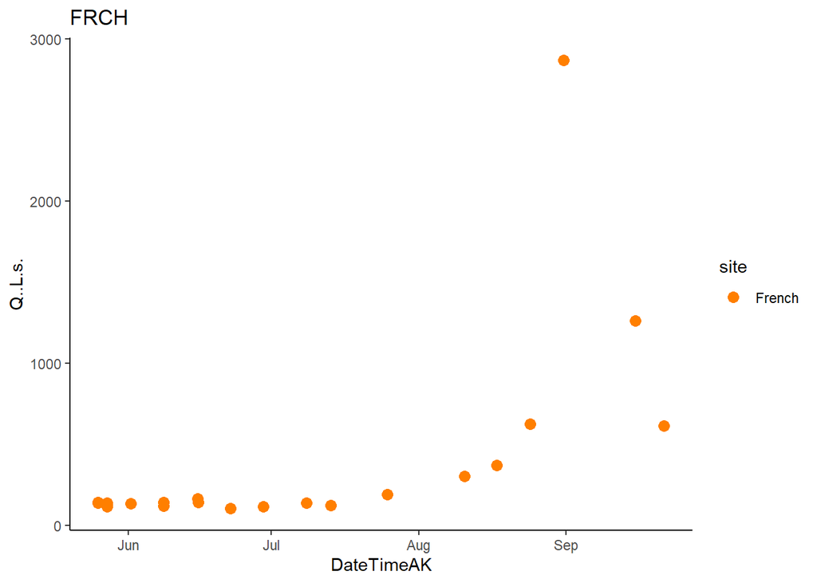

```r
### Filter FRCH ###
QSummary.FR <- QSummary %>% filter(site =="French")

ggplot(QSummary.FR) +
  geom_point(aes(x = DateTimeAK, y = Q..L.s., color = site), size=3) +
  theme_classic() +
  scale_color_manual(values=c("#FF7F00")) +
  ggtitle("FRCH")
```

```r
# trying to merge by nearest date if we have an offset point
FRCH.2015.one.dt <- setDT(FRCH.2015.one)
FRCH.2015.one.dt <- subset(FRCH.2015.one.dt, DateTimeAK < "2015-09-20 19:00:00") # removing rows that had dates corresponding to end of record that messed up the rolling nearest function
QSummary.FR.dt <- QSummary.FR

French1comb.2015 <- FRCH.2015.one.dt[QSummary.FR.dt, on = "DateTimeAK", roll = 'nearest']

FRCH1.lm.2015 <- lm(French1comb.2015$Q..L.s. ~ French1comb.2015$difference)
```

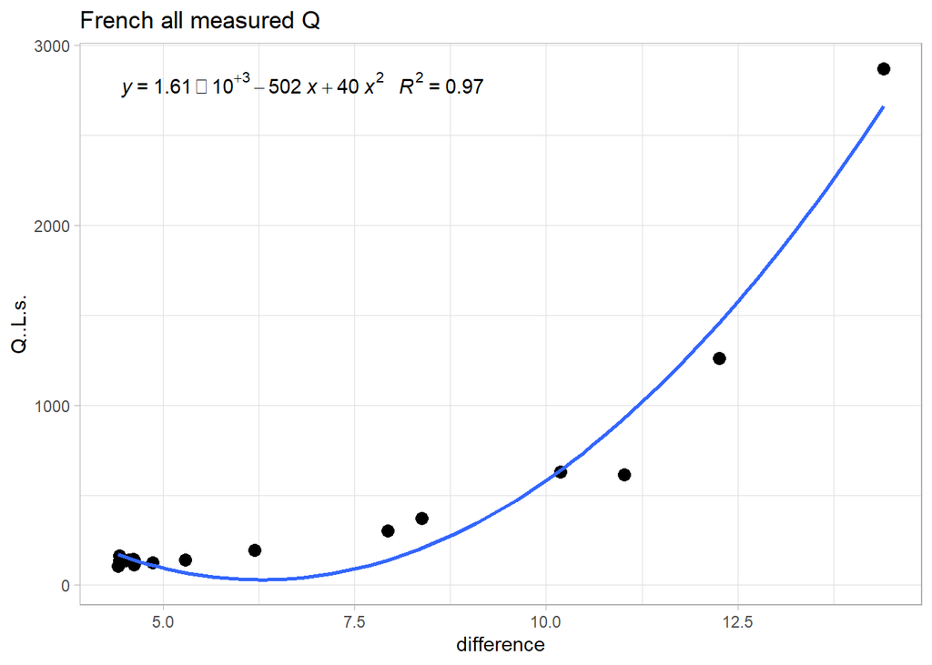

```r
# plot rating curve
frch.formula = y~ x + I(x^2)

French1comb.2015 %>% ggplot(aes(x = difference, y = Q..L.s.)) +
  geom_point(size = 3) +
  geom_smooth(method = "lm", se=FALSE, formula = frch.formula) +
  stat_poly_eq(formula = frch.formula,
               aes(label = paste(..eq.label.., ..rr.label.., sep = "~~~")),
               parse = TRUE) +
  theme_light() +
  ggtitle("French all measured Q")
```

We need to alter the quadratic term to make it not dip down like that.

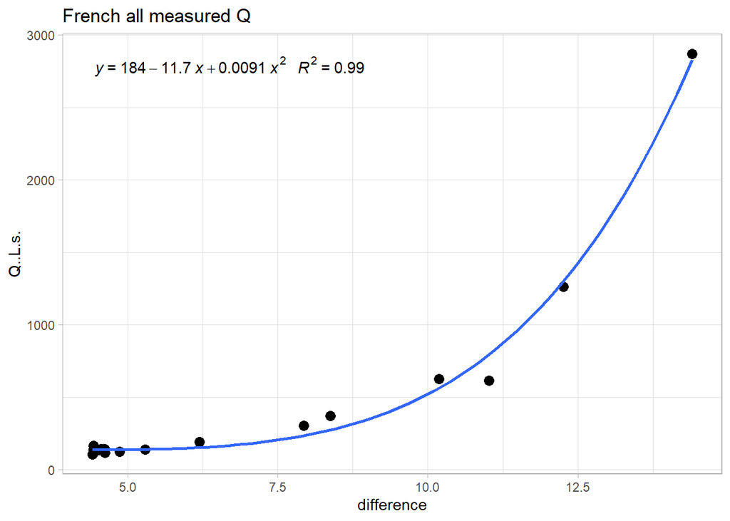

```r
# plot rating curve
frch.formula = y~ x + I(x^5/2)

French1comb.2015 %>% ggplot(aes(x = difference, y = Q..L.s.)) +
  geom_point(size = 3) +
  geom_smooth(method = "lm", se=FALSE, formula = frch.formula) +
  stat_poly_eq(formula = frch.formula,
               aes(label = paste(..eq.label.., ..rr.label.., sep = "~~~")),
               parse = TRUE) +
  theme_light() +
  ggtitle("French all measured Q")
```

```r
## Predict STRT Q
FRCH.lm.2015 <- lm(French1comb.2015$Q..L.s. ~ French1comb.2015$difference + I(French1comb.2015$difference^5/2))
summary(FRCH.lm.2015)
```

```
##
## Call:
## lm(formula = French1comb.2015$Q..L.s. ~ French1comb.2015$difference +
##     I(French1comb.2015$difference^5/2))
##
## Residuals:
##      Min       1Q   Median       3Q      Max
## -179.958  -17.736   -2.192   24.517   98.742
##
## Coefficients:
##                                      Estimate Std. Error t value Pr(>|t|)
## (Intercept)                         1.838e+02  4.818e+01   3.816  0.00127 **
## French1comb.2015$difference        -1.167e+01  8.736e+00  -1.336  0.19826
## I(French1comb.2015$difference^5/2)  9.102e-03  3.672e-04  24.785 2.31e-15 ***
## ---
## Signif. codes:  0 '***' 0.001 '**' 0.01 '*' 0.05 '.' 0.1 ' ' 1
##
## Residual standard error: 57.24 on 18 degrees of freedom
## Multiple R-squared:  0.9926, Adjusted R-squared:  0.9918
## F-statistic:  1212 on 2 and 18 DF,  p-value: < 2.2e-16
```

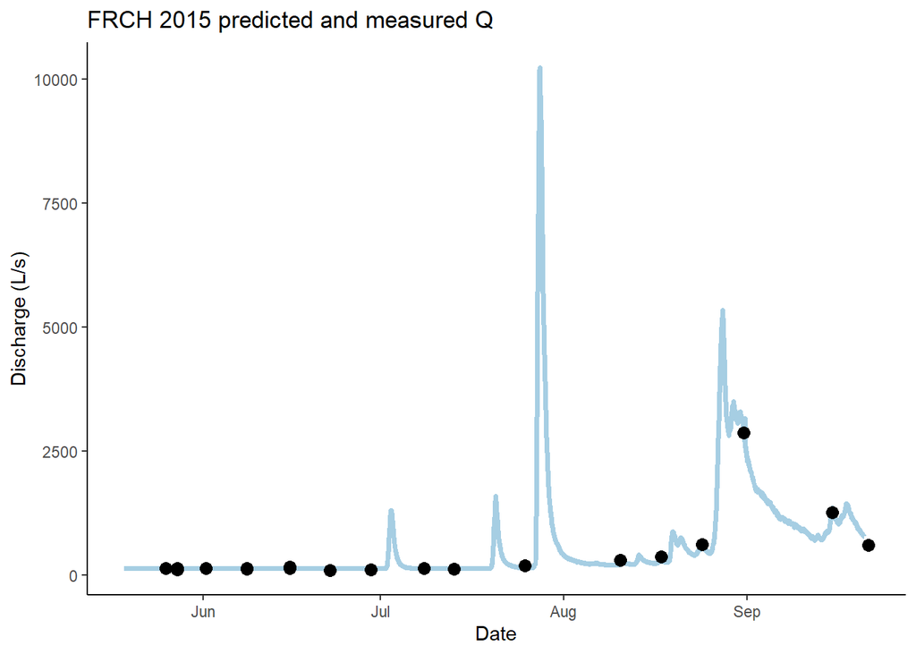

```r
FRCH.2015.one.dt$pred.frch.Q <- coef(FRCH.lm.2015)[2] * FRCH.2015.one.dt$difference + coef(FRCH.lm.2015)[1] + coef(FRCH.lm.2015)[3] * I(FRCH.2015.one.dt$difference^5/2)

FRCH.2015.one.dt <- FRCH.2015.one.dt %>% filter(!pred.frch.Q %in% NA)

# Fill in any missing predicted Q
FRCH.2015.one.dt <- na_kalman(FRCH.2015.one.dt)

FRCH.2015.one.dt %>% ggplot(aes(x = DateTimeAK, y = pred.frch.Q)) +
  geom_line(color="#A6CEE3", size=1.25) +
  geom_point(data = French1comb.2015, aes(x = DateTimeAK, y = Q..L.s.), size=3) +
  theme_classic() +
  ggtitle("FRCH 2015 predicted and measured Q") +
  xlab("Date") +
  ylab("Discharge (L/s)")
```

### Export 2015 predicted Q

```r
FRCH.2015.one.dt <- FRCH.2015.one.dt[,c(2,15,13)]
names(FRCH.2015.one.dt) <- c("DateTimeAK", "Q", "Site")
MOOS.2015.one.dt <-  MOOS.2015.one.dt[,c(2,15,13)]
names(MOOS.2015.one.dt) <- c("DateTimeAK", "Q", "Site")

Q_2015 <- rbind(FRCH.2015.one.dt, MOOS.2015.one.dt)

# Round all sites to 15 minute intervals
Q_2015$DateTimeAK <- lubridate::round_date(Q_2015$DateTimeAK, "15 minutes")
Q_2015 <- Q_2015 %>% group_by(Site, DateTimeAK) %>% summarise(Q = mean(Q))
# Fill gaps in data
DateTimeFill <- data.frame(DateTimeAK = seq(ymd_hm("
2015-05-14 00:00", tz = "America/Anchorage"),ymd_hm("2015-09-22 00:00", tz = "America/Anchorage"), by = '15 mins'))
DateTimeFill_all <- data.frame(Site = c(rep("FRCH", length(DateTimeFill$DateTimeAK)),rep("MOOS", length(DateTimeFill$DateTimeAK))), DateTimeAK = rep(DateTimeFill$DateTimeAK, 2))
Q_2015 <- full_join(Q_2015, DateTimeFill_all)
Q_2015 <- Q_2015[order(Q_2015$DateTimeAK),]

# Fill in gaps up to 15 x 10 minutes
Q_2015 <- Q_2015 %>% group_by(Site) %>% summarise(Q = na_kalman(Q, maxgap = 50),
                                                  DateTimeAK = DateTimeAK) %>% filter(DateTimeAK < "2022-09-22")
write.csv(Q_2015, here("Predicted_Discharge/2015/Predicted_Q_2015.csv"))

Q_2015$Day = format(as.POSIXct(Q_2015$DateTimeAK,format="%Y-%m-%d %H:%M:%S"),format="%Y-%m-%d")
Q_2015$Day = as.POSIXct(Q_2015$Day, "%Y-%m-%d", tz="America/Anchorage")

Q.daily.2015 <- Q_2015 %>% group_by(Site, Day) %>% summarise(Q = mean(Q))
any(is.na(Q.daily.2015))
```

```
## [1] TRUE
```

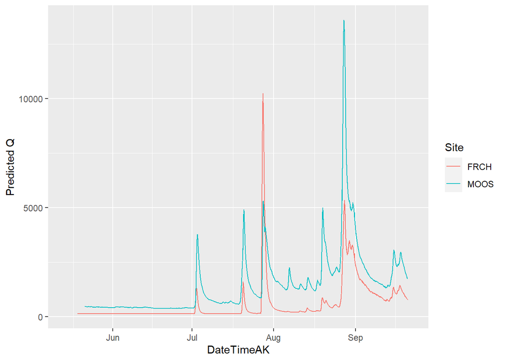

```r
write.csv(Q.daily.2015, here("Predicted_Discharge/2015/Q.daily.2015.csv"))

# Plot
Q_2015 %>% ggplot() + geom_line(aes(DateTimeAK, Q, color = Site))+ ylab("Predicted Q")
```

```r
# Check time step intervals
Q_2015_check <- Q_2015 %>% group_by(Site) %>% summarise(diff = DateTimeAK - lag(DateTimeAK),
                                                        DateTimeAK = DateTimeAK)
unique(Q_2015_check$diff)
```

```
## [1] NA 15
```

```
## Defaulting to continuous.
```

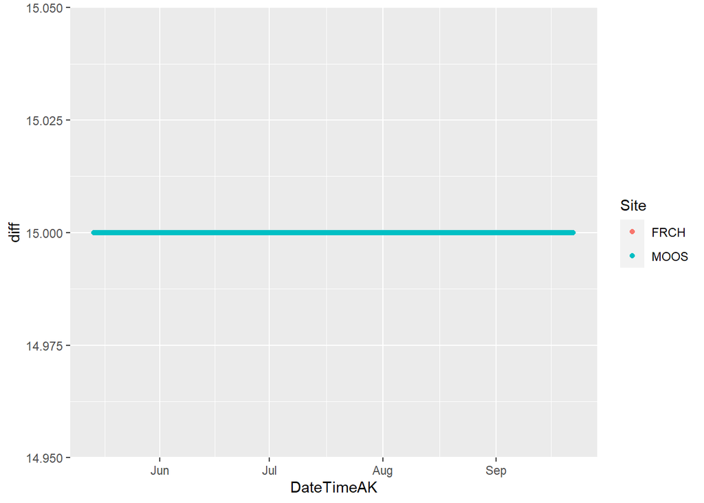

```r
Q_2015_check %>% ggplot(aes(DateTimeAK, diff, color = Site)) + geom_point()# + ylim(0,60)
```

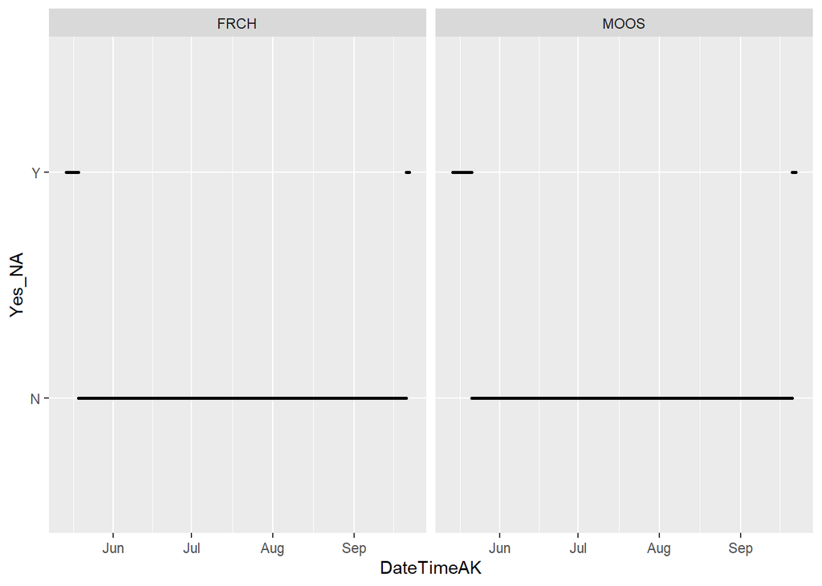

```r
# Check length of consecutive NA's
Q_2015_check_NA <- Q_2015 %>% mutate(Yes_NA = ifelse(Q %in% NA, "Y", "N"))

Q_2015_check_NA %>% #filter(Site == "VAUL") %>%
  #filter( DateTimeAK > "2022-09-20" & DateTimeAK < "2022-10-01") %>%
  ggplot(aes(DateTimeAK, Yes_NA)) + geom_point(size = 0.5) + facet_wrap(~Site)
```